# ACM - TD - *correction*

## Données `poison`

Nous allons utiliser le jeu de données [`poison`](https://rdrr.io/cran/FactoMineR/man/poison.html). Celui-ci concerne une étude sur une intoxication alimentaire d’enfants dans une école.

|  | Age | Time | Sick | Sex | Nausea | Vomiting | Abdominals | Fever | Diarrhae | Potato | Fish | Mayo | Courgette | Cheese | Icecream |
| --- | --- | --- | --- | --- | --- | --- | --- | --- | --- | --- | --- | --- | --- | --- | --- |
| 1 | 9 | 22 | Sick_y | F | Nausea_y | Vomit_n | Abdo_y | Fever_y | Diarrhea_y | Potato_y | Fish_y | Mayo_y | Courg_y | Cheese_y | Icecream_y |
| 2 | 5 | 0 | Sick_n | F | Nausea_n | Vomit_n | Abdo_n | Fever_n | Diarrhea_n | Potato_y | Fish_y | Mayo_y | Courg_y | Cheese_n | Icecream_y |
| 3 | 6 | 16 | Sick_y | F | Nausea_n | Vomit_y | Abdo_y | Fever_y | Diarrhea_y | Potato_y | Fish_y | Mayo_y | Courg_y | Cheese_y | Icecream_y |
| 4 | 9 | 0 | Sick_n | F | Nausea_n | Vomit_n | Abdo_n | Fever_n | Diarrhea_n | Potato_y | Fish_y | Mayo_n | Courg_y | Cheese_y | Icecream_y |
| 5 | 7 | 14 | Sick_y | M | Nausea_n | Vomit_y | Abdo_y | Fever_y | Diarrhea_y | Potato_y | Fish_y | Mayo_y | Courg_y | Cheese_y | Icecream_y |
| 6 | 72 | 9 | Sick_y | M | Nausea_n | Vomit_n | Abdo_y | Fever_y | Diarrhea_y | Potato_y | Fish_n | Mayo_y | Courg_y | Cheese_y | Icecream_y |
| 7 | 5 | 16 | Sick_y | F | Nausea_n | Vomit_y | Abdo_y | Fever_y | Diarrhea_y | Potato_y | Fish_y | Mayo_y | Courg_y | Cheese_y | Icecream_y |
| 8 | 10 | 8 | Sick_y | F | Nausea_y | Vomit_y | Abdo_y | Fever_y | Diarrhea_y | Potato_y | Fish_y | Mayo_y | Courg_y | Cheese_y | Icecream_y |
| 9 | 5 | 20 | Sick_y | M | Nausea_y | Vomit_n | Abdo_y | Fever_y | Diarrhea_y | Potato_y | Fish_y | Mayo_y | Courg_y | Cheese_y | Icecream_y |
| 10 | 11 | 12 | Sick_y | M | Nausea_n | Vomit_y | Abdo_n | Fever_y | Diarrhea_y | Potato_y | Fish_y | Mayo_y | Courg_y | Cheese_y | Icecream_y |

[output cut: 45 more lines]

Nous allons réaliser une ACM sur ces données, avec les quatre premières variables en tant qu’illustratives. Cela nous permettra donc de situer les symptômes et aliments consommés au regard des informations de ces variables (âge, sexe, intoxication). Et nous choississons aussi de placer la consommation de poisson en variable supplémentaire, pour qu’elle ne perturbe pas l’analyse.

Comme pour la première ACM, le premier plan factoriel explique uniquement 51% de la variance. Et le dernier saut important se situe à la huitième dimension. Si nous souhaitions compléter cette analyse par une autre, il serait nécessaire de conserver ces 8 dimensions. Pour notre cas, nous allons nous contenter des 3 premiers axes, qui expliquent à eux seuls 62% de la variance.

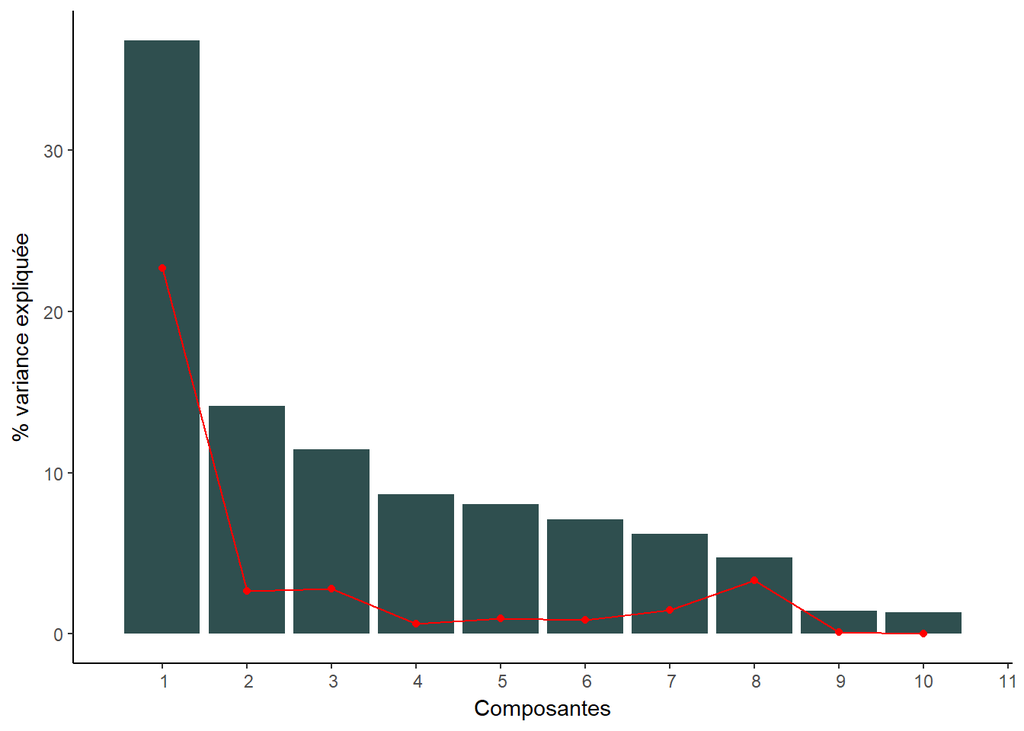

On retrouve presque les mêmes plans factoriels que lors de l’ACM sans variables illustratives. Nous allons les détailler plus tard.

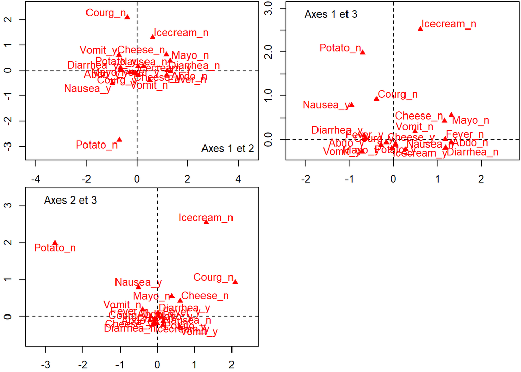

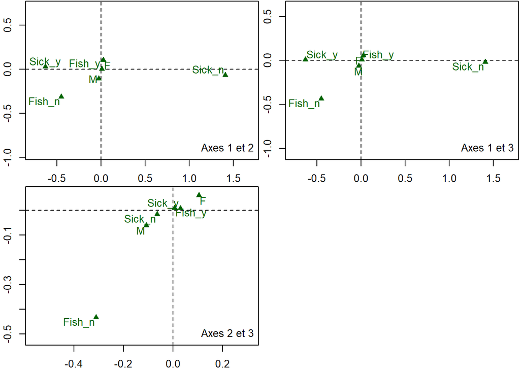

L’axe 2 oppose la *non*-consommation de patates (en négatif) à la *non*-consommation de courgettes et de crême glacée.

Enfin, l’axe 3, place la *non*-consommation de patates et de crême glacée loin du centre de gravité.

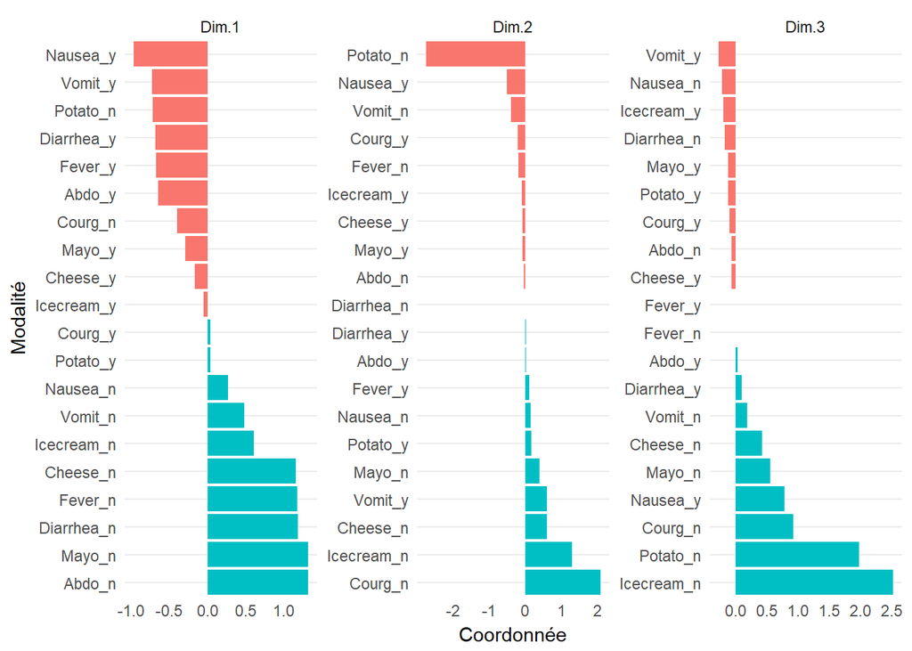

Nous pouvons en conclure que cette analyse est intéressante sur l’axe 1 (opposition entre malades et *non*-malades). Concernant l’axe 2 et 3, ceux-ci sont fortement influencés encore par des modalités peu présentes (*non*-consommation de patates - 3 individus -, de crême glacée - 4 individus -, et de courgettes - 5 individus).